# Week 2 Lecture 2: Social Progress Index with PCA

Stefano Galelli

Term 5, 2022

# 1 Introduction

**New York Times opinion column:**

https://www.nytimes.com/2020/09/09/opinion/united-states-social-progress.html

**Social Progress Imperative**

https://www.socialprogress.org/

Quoting from their report:The Social Progress Index is a well-established measure, published since 2013, that is meant to catalyze improvement and drive action by presenting social outcome data in a useful and reliable way. Composed of multiple dimensions, the Social Progress Index can be used to benchmark success and provide a holistic, transparent, outcome-based measure of a country’s well-being that is independent of economic indicators. Policymakers, businesses, and countries’ citizens alike can use it to compare their country against others on different facets of social progress, allowing the identification of specific areas of strength or weakness.

We look at recent social progress data from 2011-2020. Among the 192 countries listed in 2020, 163 are ranked according to Social Progress Index. We will consider this data set for our study.

## 1.1 Motivation

Can we come up with a reasonable index of social progress from the data that we have.

## 1.2 Read data

```r
### install.packages("factoextra")
rm(list=ls())
### Read data
sp2011to2020 <- read.csv("socprog2020.csv")
#sp2011to2020
### data check
#head(sp2011to2020)
dim(sp2011to2020)
```

Note that there is a ranking of the countries and a social progress index mentioned here.

## 1.3 Data processing

We select the relevant parts for use. First we take the country information and remove first few columns. Keep year 2020 and *Ranked* ones.

```r
spi2020<-subset(sp2011to2020,SPI.year =="2020" & Status=="Ranked")
rownames(spi2020)<-spi2020[,2]
spirank<-spi2020[,1]    #### to be used later
spi2020<-spi2020[,-c(1:6)]
dim(spi2020)
```

```
## [1] 163  65
```

```r
#spi2020
```

Then we remove columns which do not have available data (remove “NA”).

```r
NAobject<-colnames(spi2020)[apply(is.na(spi2020),2,any)]
spi2020<-spi2020[,!names(spi2020) %in% NAobject]
### check
dim(spi2020)
#head(spi2020)
```

## 1.4 Singapore

How is Singapore fairing here? What about the US?

```r
#rownames(spi2020)
spi2020["Singapore",]
spi2020["United States",]
summary(spi2020$Access.to.Basic.Knowledge)
# spi2020[which.max(spi2020$Access.to.Basic.Knowledge),]
```

We can also compute average over all countries for the different attributes.

```r
#names(spi2020)
Stats<-as.data.frame(cbind(apply(spi2020, 2, mean),apply(spi2020, 2, "median"),apply(spi2020, 2, "sd")))
colnames(Stats)<-c("mean", "median","std.dev")
#head(Stats)
# View(Stats)
```

# 2 PCA without scaling

Let us do some basic principal component analysis for social progress.

```r
?prcomp
```

```
## starting httpd help server ... done
```

```r
pr.out.ns=prcomp(spi2020, scale=F)
pr.out.ns$rotation     ### gives the weights for the PCAs (eigenvectors)
pr.out.ns$x[1:10,1:5]  ### gives PCA value for 1st 10 countries and first 5 PCAs
```

## 2.1 Scree plot

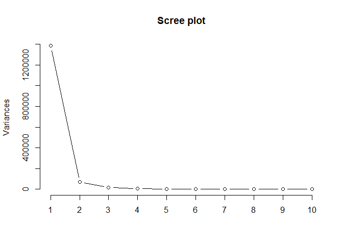

```r
#plot scree: plot of variance of each PCA
plot(pr.out.ns, type="l", main="Scree plot")
```

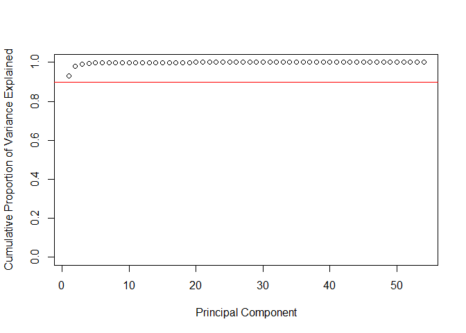

```
## integer(0)
```

```r
#plot cumulative prop: proportional variance (cumulative)
pr.var.ns=pr.out.ns$sdev^2
pve.ns=pr.out.ns$sdev^2/sum(pr.out.ns$sdev^2)
plot(cumsum(pve.ns), xlab="Principal Component", ylab="Cumulative Proportion of Variance Explained", ylim=c(0,1),type='b')+abline(h=0.9,col="red")
```

```r
# first PC explanation
pve.ns[1]
```

```
## [1] 0.9318276
```

From the `Scree plot’ and the ‘Cumulative Proportion plot’: The first PC actually explains 93% of the variability.

Let us look at the loadings for each and the PCA scores for the countries. We look at the coefficients of the top and bottom 5. Also we also look at the top and bottom scoring countries for each PC.

## 2.2 Significant loadings, country rankings

```r
#pr.out.ns$x
#pr.out.ns$rotation
sp.pc<-data.frame(pr.out.ns$x[,1:2])
sp.pc[order(-sp.pc$PC1),]
sp.pc[order(-sp.pc$PC2),]
dim(spi2020)

co.sp.pc<-data.frame(pr.out.ns$rotation[,1:2])
#View(co.sp.pc)
#View(co.sp.pc[order(-co.sp.pc[,1]),][c(1:5,50:54),])
#View(co.sp.pc[order(-co.sp.pc[,2]),][c(1:5,50:54),])
#View(Stats)
```

We observe that PC1 explains 93% of the variation and moreover PC1 is dominated by Green house gas emission. So countries like China, US, India, Brazil are clustered and dominate together. On the other hand PC2 seems dominated by mortality rates from infectious disease, child birth and other premature deaths.

# 3 PCA with scaling

Clearly, these are the components with very high variance anyway. Hence what is often suggested here is to standardize or scale the data.

## 3.1 Scree plot

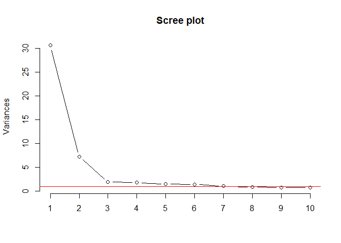

```r
pr.out=prcomp(spi2020, scale=TRUE)
plot(pr.out, type="l", main="Scree plot")
plot(pr.out, type="l", main="Scree plot")+abline(h=1,col="red")
```

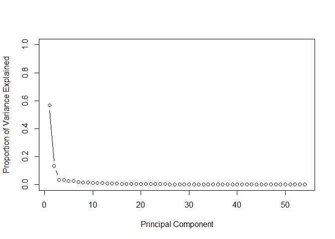

```r
pr.var=pr.out$sdev^2
pr.var
pve=pr.var/sum(pr.var)
pve
plot(pve, xlab="Principal Component", ylab="Proportion of Variance Explained", ylim=c(0,1),type='b')
```

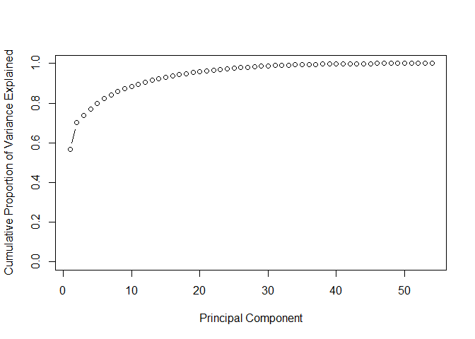

```r
plot(cumsum(pve), xlab="Principal Component", ylab="Cumulative Proportion of Variance Explained", ylim=c(0,1),type='b')  #+ abline(h=0.8,col="red")+abline(v=6,col="blue")
```

## 3.2 Significant loadings, country rankings

```r
## Which components and which country?
sp4<-data.frame(pr.out$x[,1:4])
sp4[order(-sp4$PC1),]
```

```
##                                         PC1         PC2          PC3
## Norway                          8.645218370 -2.54976925 -0.382451638
## Switzerland                     8.532802087 -1.97772651 -0.017725472
## Denmark                         8.512089543 -2.54123727  0.077977589
## Sweden                          8.360127703 -2.45000470 -0.238627096
## Finland                         8.274310193 -2.57454808 -0.225952872
## Iceland                         8.134080264 -1.56394636 -1.077423591
## Canada                          8.014893145 -1.99819471  0.441784246
## Japan                           7.929151555 -0.94698561  1.769709919
## New Zealand                     7.912629077 -2.38248071 -0.333850417
## Netherlands                     7.906187368 -1.71866001 -0.060190653
## Luxembourg                      7.891970429 -2.23641621 -0.830656770
## Germany                         7.886672549 -1.86432448  1.443125945
## Australia                       7.886454988 -1.60891066  0.439158883
## Ireland                         7.690507529 -2.05038573 -0.592468496
## Belgium                         7.470027182 -2.12934826 -0.212746999
## Austria                         7.401218491 -0.89853499 -0.468665487
## Korea, Republic of              7.334786186 -0.79034416  0.857239441
## France                          7.236351494 -1.17304175  0.758251827
## United Kingdom                  7.194872524 -1.08104348  1.552359061
## Spain                           7.170274538 -1.65229956  0.373037545
## Italy                           7.167845821 -1.69541259  0.562025474
## Cyprus                          7.014563273 -1.09734158 -0.335655649
## Estonia                         6.959095678 -1.52188315 -0.463835196
## Slovenia                        6.937131521 -1.33209309 -0.698292563
## Portugal                        6.894115406 -2.13128000 -0.663906609
## United States                   6.552405115  0.68278275  8.544873528
## Czechia                         6.551461951 -0.85877072 -0.275729536
## Greece                          6.443426655 -1.56841317 -0.132427543
## Singapore                       6.303479317  1.58895878 -1.062120115
## Malta                           6.146187326 -0.77626930 -1.039044061
## Lithuania                       5.817886469 -1.19711608 -0.416700127
## Poland                          5.728917887 -0.19216201  0.147860163
## Israel                          5.597621407  0.31258941 -0.252770372
## Costa Rica                      5.391038377 -2.00463803 -0.539613800
## Uruguay                         5.313471677 -1.86067546  0.026778016
## Slovakia                        5.304913651 -0.41935569 -0.274050114
## Latvia                          5.227353899 -1.00479208 -0.328113704
## Croatia                         5.078721382  0.21513192 -0.834525545
## Chile                           4.963798715 -0.39262112  0.087824517
```

[output cut: 273 more lines]

```
## Pakistan                       0.43863360
## Madagascar                     0.04269696
## Congo, Republic of            -0.49063424
## Guinea-Bissau                  0.06815870
## Papua New Guinea               3.06903521
## Niger                          0.35285505
## Afghanistan                    2.25700104
## Congo, Democratic Republic of -1.53486314
## Guinea                        -1.10487583
## Burundi                       -1.82118262
## Eritrea                       -1.27577347
## Somalia                       -0.83617957
## Chad                          -1.76735401
## South Sudan                   -2.36031272
## Central African Republic       0.79228168
```

```r
cosp4<-data.frame(pr.out$rotation[,1:4])
cosp4[order(-cosp4[,1]),]
```

```
##                                                                                                PC1
## Foundations.of.Wellbeing                                                                0.17588076
## Basic.Human.Needs                                                                       0.17195776
## Access.to.essential.services...0.none..100.full.coverage.                               0.17177645
## Opportunity                                                                             0.16934968
## Health.and.Wellness                                                                     0.16637512
## Access.to.Information.and.Communications                                                0.16633731
## Personal.Freedom.and.Choice                                                             0.16623175
## Nutrition.and.Basic.Medical.Care                                                        0.16538529
## Water.and.Sanitation                                                                    0.16427357
## Shelter                                                                                 0.16287627
## Access.to.Advanced.Education                                                            0.16226536
## Internet.users....of.pop..                                                              0.16206190
## Access.to.Basic.Knowledge                                                               0.15745950
## Life.expectancy.at.60..years.                                                           0.15431712
## Women.with.advanced.education....                                                       0.14811438
## Personal.Safety                                                                         0.14671615
## Access.to.quality.healthcare..0.unequal..4.equal.                                       0.14592976
## Access.to.online.governance..0.low..1.high.                                             0.14314397
## Access.to.electricity....of.pop..                                                       0.14166033
## Access.to.quality.education..0.unequal..4.equal.                                        0.13321164
## Access.to.justice..0.non.existent..1.observed.                                          0.13200031
## Citable.documents                                                                       0.13034271
## Political.killings.and.torture..0.low.freedom..1.high.freedom.                          0.12892541
## Personal.Rights                                                                         0.12844478
## Inclusiveness                                                                           0.12802533
## Property.rights.for.women..0.no.right..5.full.rights.                                   0.12737664
## Political.rights..0.no.rights..40.full.rights.                                          0.12719184
## Mobile.telephone.subscriptions..subscriptions.100.people.                               0.11593612
## Equality.of.political.power.by.gender..0.unequal.power..4.equal.power.                  0.10317451
## Equality.of.political.power.by.socioeconomic.position..0.unequal.power..4.equal.power.  0.09987346
## Equality.of.political.power.by.social.group..0.unequal.power..4.equal.power.            0.09955379
## Freedom.of.expression..0.no.freedom..1.full.freedom.                                    0.09680554
## Media.censorship..0.frequent..4.rare.                                                   0.09118232
## Environmental.Quality                                                                   0.07943496
## Freedom.of.religion..0.no.freedom..4.full.freedom.                                      0.06870666
## Quality.weighted.universities..points.                                                  0.05052880
## Biome.protection                                                                        0.04542126
## Greenhouse.gas.emissions..total.CO2.equivalents.                                        0.01390375
## Outdoor.air.pollution.attributable.deaths..deaths.100.000.                             -0.04680620
```

[output cut: 165 more lines]

```
## Discrimination.and.violence.against.minorities..0.low..10.high.                        -0.0840100275
## Particulate.matter                                                                      0.1534259375
## Premature.deaths.from.non.communicable.diseases..deaths.100.000.                        0.3382329345
## Women.with.no.schooling                                                                 0.0145751757
## Early.marriage....of.women.                                                            -0.0615872541
## Traffic.deaths..deaths.100.000.                                                         0.1019644852
## Deaths.from.infectious.diseases..deaths.100.000.                                       -0.0472601592
## Unsafe.water..sanitation.and.hygiene.attributable.deaths..per.100.000.pop..            -0.0602165071
## Maternal.mortality.rate..deaths.100.000.live.births.                                    0.0328189679
## Vulnerable.employment....of.employees.                                                 -0.0820859253
## Child.mortality.rate..deaths.1.000.live.births.                                        -0.0174518302
## Child.stunting....of.children.                                                         -0.0103075644
## Populations.using.unsafe.or.unimproved.sanitation....                                   0.0155000508
## Populations.using.unsafe.or.unimproved.water.sources....                                0.0007476995
## Household.air.pollution.attributable.deaths..deaths.100.000.                            0.1321792383
```

## 3.3 Correlation plot

```r
 ## Correlation plot
 ## Check Stats earlier
 library(corrplot)
 corspi<-cor(spi2020)
 dim(corspi)
```

```
## [1] 54 54
```

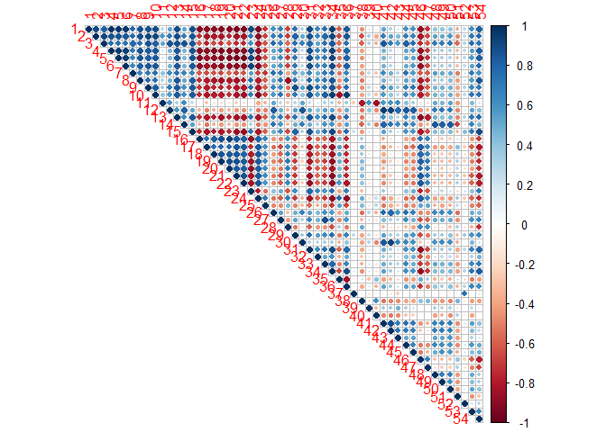

```r
 rownames(corspi)<-colnames(corspi)<-1:54
 corrplot(corspi,type="upper")
```

# 4 PCA with only the core quantities

Now, we can go back to the documentation of the data and see that the primary components here are not the core metrics computed. There are three big dimensions: 1. Basic Human Needs 2. Foundations of Well-being 3. Opportunity

The SPI is an average of these three quantities which are again averages of four different quantities each. We remove this to have the core data to study.

```r
bigdim<-c("Basic.Human.Needs","Foundations.of.Wellbeing","Opportunity")
medcomp<-c("Nutrition.and.Basic.Medical.Care","Water.and.Sanitation","Shelter","Personal.Safety","Access.to.Basic.Knowledge","Access.to.Information.and.Communications","Health.and.Wellness","Environmental.Quality","Personal.Rights","Personal.Freedom.and.Choice","Inclusiveness","Access.to.Advanced.Education")
spi2020core<-spi2020[,!names(spi2020) %in% c(bigdim,medcomp)]
dim(spi2020core)
```

```
## [1] 163  39
```

## 4.1 Correlation plot

```r
corspicore<-cor(spi2020core)
rownames(corspicore)<-colnames(corspicore)<-1:dim(corspicore)
```

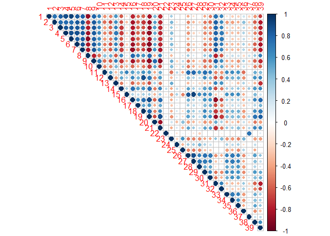

```r
corrplot(corspicore,type="upper")
```

Now we conduct a PCA. What we observe is that the PC1 explains 50.0% PC2 explains 14.2% PC3 explains 4.6%  
PC4 explains 3.7%

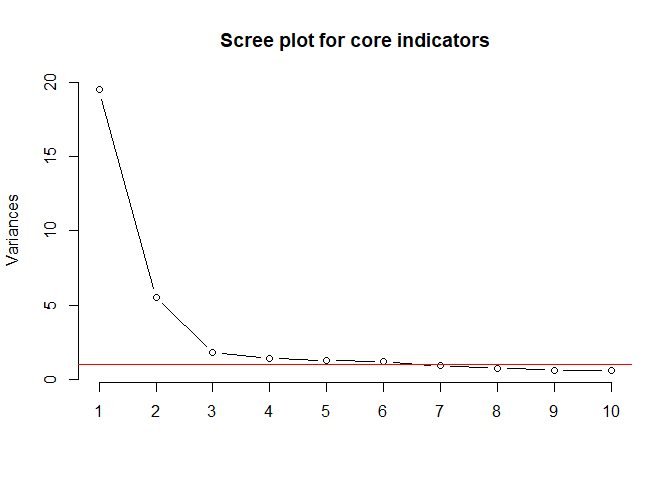

```
## integer(0)
```

```r
pr.out.core=prcomp(spi2020core, scale=TRUE)
#pr.out.core
plot(pr.out.core, type="l", main="Scree plot for core indicators") +abline(h=1,col="red")
```

```r
pr.var.core=pr.out.core$sdev^2
#pr.var.core
pve.core=pr.var.core/sum(pr.var.core)
pve.core
```

```
##  [1] 0.4995375309 0.1418431236 0.0458570024 0.0367125851 0.0324533884
##  [6] 0.0307786779 0.0236679525 0.0192697154 0.0160904297 0.0149292014
## [11] 0.0132099724 0.0127548837 0.0109588234 0.0100919687 0.0091445464
## [16] 0.0084845289 0.0080622265 0.0076195313 0.0069743322 0.0057231996
## [21] 0.0051095331 0.0045197027 0.0043852010 0.0037644713 0.0036404605
## [26] 0.0035837786 0.0029618049 0.0028930647 0.0023884956 0.0021216353
## [31] 0.0019817646 0.0018434924 0.0014749256 0.0012593072 0.0011036603
## [36] 0.0009343887 0.0007930752 0.0006008931 0.0004767247
```

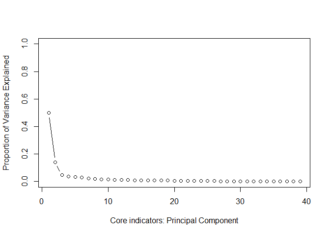

```r
plot(pve.core, xlab="Core indicators: Principal Component", ylab="Proportion of Variance Explained", ylim=c(0,1),type='b')
```

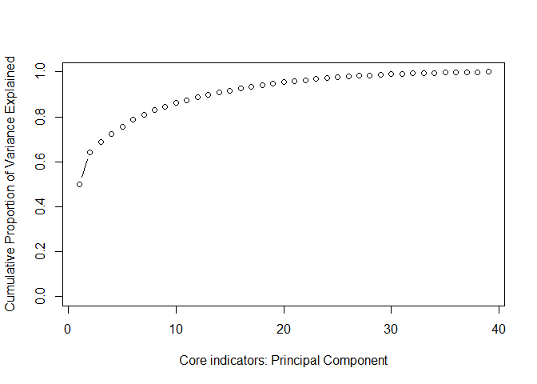

```r
plot(cumsum(pve.core), xlab="Core indicators: Principal Component", ylab="Cumulative Proportion of Variance Explained", ylim=c(0,1),type='b')
```

```r
n<-dim(spi2020core)[1]
k<-dim(spi2020core)[2]

nup<-5
kup<-5

sp4.core<-data.frame(pr.out.core$x[,1:4])
cosp4.core<-data.frame(pr.out.core$rotation[,1:4])
#sp4.core
#cosp4.core

cosp4.core[order(-cosp4.core[,1]),][c(1:kup,(k-kup+1):k),]
```

```
##                                                                     PC1
## Access.to.essential.services...0.none..100.full.coverage.     0.2149302
## Internet.users....of.pop..                                    0.2026778
## Life.expectancy.at.60..years.                                 0.1935808
## Women.with.advanced.education....                             0.1854162
## Access.to.quality.healthcare..0.unequal..4.equal.             0.1837150
## Child.mortality.rate..deaths.1.000.live.births.              -0.1962882
## Child.stunting....of.children.                               -0.1981282
## Populations.using.unsafe.or.unimproved.sanitation....        -0.1983278
## Populations.using.unsafe.or.unimproved.water.sources....     -0.2008027
## Household.air.pollution.attributable.deaths..deaths.100.000. -0.2072695
##                                                                        PC2
## Access.to.essential.services...0.none..100.full.coverage.     0.0789205849
## Internet.users....of.pop..                                    0.0942708493
## Life.expectancy.at.60..years.                                 0.0445171494
## Women.with.advanced.education....                             0.1071345527
## Access.to.quality.healthcare..0.unequal..4.equal.            -0.0006333655
## Child.mortality.rate..deaths.1.000.live.births.              -0.1380039959
## Child.stunting....of.children.                               -0.0767280502
## Populations.using.unsafe.or.unimproved.sanitation....        -0.1271563875
## Populations.using.unsafe.or.unimproved.water.sources....     -0.1313111425
## Household.air.pollution.attributable.deaths..deaths.100.000. -0.0695212094
##                                                                        PC3
## Access.to.essential.services...0.none..100.full.coverage.    -0.0351548442
## Internet.users....of.pop..                                    0.0129074396
## Life.expectancy.at.60..years.                                -0.1114615030
## Women.with.advanced.education....                             0.0347238173
## Access.to.quality.healthcare..0.unequal..4.equal.             0.1204774834
## Child.mortality.rate..deaths.1.000.live.births.              -0.0413368295
## Child.stunting....of.children.                               -0.0252755209
## Populations.using.unsafe.or.unimproved.sanitation....        -0.0006977791
## Populations.using.unsafe.or.unimproved.water.sources....     -0.0227135819
## Household.air.pollution.attributable.deaths..deaths.100.000.  0.0359118895
##                                                                       PC4
## Access.to.essential.services...0.none..100.full.coverage.     0.081550988
## Internet.users....of.pop..                                   -0.002207984
## Life.expectancy.at.60..years.                                 0.281577792
## Women.with.advanced.education....                            -0.047297262
## Access.to.quality.healthcare..0.unequal..4.equal.             0.028172676
## Child.mortality.rate..deaths.1.000.live.births.               0.019968049
## Child.stunting....of.children.                                0.001509685
## Populations.using.unsafe.or.unimproved.sanitation....        -0.030489615
## Populations.using.unsafe.or.unimproved.water.sources....     -0.004984459
## Household.air.pollution.attributable.deaths..deaths.100.000. -0.170344099
```

```r
topbotPC1<-row.names(cosp4.core[order(-cosp4.core[,1]),])[c(1:kup,(k-kup+1):k)]
sp4.core[order(-sp4.core$PC1),][c(1:nup,(n-nup+1):n),]
```

```
##                                 PC1         PC2          PC3         PC4
## Switzerland                6.858366 -1.70862573 -0.181245574  1.07287463
## Norway                     6.808964 -2.13930120 -0.042996718  1.28852001
## Denmark                    6.758297 -2.14512579 -0.005562355  0.64672492
## Sweden                     6.648665 -2.02548438 -0.075061402  0.90513260
## Finland                    6.511241 -2.13670917 -0.097179583  0.82755250
## Eritrea                   -9.027385  1.67786767  0.158041054  1.33590317
## Somalia                   -9.472981  0.02828376 -0.518160082  0.09536742
## Chad                     -10.126543 -0.76132793 -1.039901256  1.95672787
## South Sudan              -10.183150 -0.13902911 -0.692942442  2.20041152
## Central African Republic -11.074523 -4.25179065 -0.485218239 -1.14463568
```

```r
topbotind1<-row.names(sp4.core[order(-sp4.core$PC1),])[c(1:nup,(n-nup+1):n)]

cosp4.core[order(-cosp4.core[,2]),][c(1:kup,(k-kup+1):k),]
```

```
##                                                                                                PC1
## Outdoor.air.pollution.attributable.deaths..deaths.100.000.                             -0.05986364
## Access.to.electricity....of.pop..                                                       0.17698543
## Discrimination.and.violence.against.minorities..0.low..10.high.                        -0.11092479
## Particulate.matter                                                                     -0.12937206
## Greenhouse.gas.emissions..total.CO2.equivalents.                                        0.01691540
## Equality.of.political.power.by.socioeconomic.position..0.unequal.power..4.equal.power.  0.12553303
## Political.rights..0.no.rights..40.full.rights.                                          0.16055804
## Media.censorship..0.frequent..4.rare.                                                   0.11601363
## Freedom.of.religion..0.no.freedom..4.full.freedom.                                      0.08742914
## Freedom.of.expression..0.no.freedom..1.full.freedom.                                    0.12345018
##                                                                                               PC2
## Outdoor.air.pollution.attributable.deaths..deaths.100.000.                              0.2616713
## Access.to.electricity....of.pop..                                                       0.1797031
## Discrimination.and.violence.against.minorities..0.low..10.high.                         0.1354798
## Particulate.matter                                                                      0.1283185
## Greenhouse.gas.emissions..total.CO2.equivalents.                                        0.1224128
## Equality.of.political.power.by.socioeconomic.position..0.unequal.power..4.equal.power. -0.2391419
## Political.rights..0.no.rights..40.full.rights.                                         -0.2446720
## Media.censorship..0.frequent..4.rare.                                                  -0.2934144
## Freedom.of.religion..0.no.freedom..4.full.freedom.                                     -0.3011012
## Freedom.of.expression..0.no.freedom..1.full.freedom.                                   -0.3159830
##                                                                                                PC3
## Outdoor.air.pollution.attributable.deaths..deaths.100.000.                              0.17223387
## Access.to.electricity....of.pop..                                                       0.06452193
## Discrimination.and.violence.against.minorities..0.low..10.high.                        -0.14778932
## Particulate.matter                                                                     -0.04123667
## Greenhouse.gas.emissions..total.CO2.equivalents.                                       -0.62115159
## Equality.of.political.power.by.socioeconomic.position..0.unequal.power..4.equal.power. -0.01651400
## Political.rights..0.no.rights..40.full.rights.                                         -0.03773278
## Media.censorship..0.frequent..4.rare.                                                  -0.03988198
## Freedom.of.religion..0.no.freedom..4.full.freedom.                                      0.06082850
## Freedom.of.expression..0.no.freedom..1.full.freedom.                                   -0.02599916
##                                                                                                PC4
## Outdoor.air.pollution.attributable.deaths..deaths.100.000.                             -0.42794367
## Access.to.electricity....of.pop..                                                      -0.14609109
## Discrimination.and.violence.against.minorities..0.low..10.high.                         0.03164456
## Particulate.matter                                                                     -0.07265399
## Greenhouse.gas.emissions..total.CO2.equivalents.                                       -0.22763944
## Equality.of.political.power.by.socioeconomic.position..0.unequal.power..4.equal.power. -0.04260580
## Political.rights..0.no.rights..40.full.rights.                                         -0.11490293
## Media.censorship..0.frequent..4.rare.                                                  -0.11661593
## Freedom.of.religion..0.no.freedom..4.full.freedom.                                     -0.03415892
## Freedom.of.expression..0.no.freedom..1.full.freedom.                                   -0.14618712
```

```r
topbotPC2<-row.names(cosp4.core[order(-cosp4.core[,2]),])[c(1:kup,(k-kup+1):k)]
sp4.core[order(-sp4.core$PC2),][c(1:nup,(n-nup+1):n),]
```

```
##                                  PC1       PC2         PC3        PC4
## China                     -0.2580826  7.231041 -9.65683845 -2.7758740
## Saudi Arabia              -1.0323350  7.196281  0.31618898  0.5731411
## Bahrain                   -0.1508929  6.497134  0.63331398  0.8078687
## Turkmenistan              -2.6981986  5.712816  1.68801283 -0.1190820
## Qatar                      1.0982687  5.145732  1.11903836  0.6400036
## Liberia                   -4.3505646 -4.243035 -0.47472718 -0.2592933
## Central African Republic -11.0745233 -4.251791 -0.48521824 -1.1446357
## Benin                     -3.7818475 -4.607834 -0.08266105 -0.4002749
## Sierra Leone              -5.4948161 -4.737386 -0.47767221 -0.5239970
## Niger                     -6.9299027 -4.913103 -1.25498456  0.4834563
```

```r
topbotind2<-row.names(sp4.core[order(-sp4.core$PC2),])[c(1:nup,(n-nup+1):n)]

cosp4.core[order(-cosp4.core[,3]),][c(1:kup,(k-kup+1):k),]
```

```
##                                                                          PC1
## Premature.deaths.from.non.communicable.diseases..deaths.100.000. -0.14672278
## Outdoor.air.pollution.attributable.deaths..deaths.100.000.       -0.05986364
## Access.to.quality.education..0.unequal..4.equal.                  0.16781792
## Access.to.quality.healthcare..0.unequal..4.equal.                 0.18371498
## Mobile.telephone.subscriptions..subscriptions.100.people.         0.14495767
## Life.expectancy.at.60..years.                                     0.19358077
## Discrimination.and.violence.against.minorities..0.low..10.high.  -0.11092479
## Access.to.online.governance..0.low..1.high.                       0.17802385
## Greenhouse.gas.emissions..total.CO2.equivalents.                  0.01691540
## Quality.weighted.universities..points.                            0.06268489
##                                                                            PC2
## Premature.deaths.from.non.communicable.diseases..deaths.100.000.  0.0115124410
## Outdoor.air.pollution.attributable.deaths..deaths.100.000.        0.2616713345
## Access.to.quality.education..0.unequal..4.equal.                 -0.0127899656
## Access.to.quality.healthcare..0.unequal..4.equal.                -0.0006333655
## Mobile.telephone.subscriptions..subscriptions.100.people.         0.0725287950
## Life.expectancy.at.60..years.                                     0.0445171494
## Discrimination.and.violence.against.minorities..0.low..10.high.   0.1354798221
## Access.to.online.governance..0.low..1.high.                       0.0362676586
## Greenhouse.gas.emissions..total.CO2.equivalents.                  0.1224127934
## Quality.weighted.universities..points.                            0.0561096542
##                                                                          PC3
## Premature.deaths.from.non.communicable.diseases..deaths.100.000.  0.17395939
## Outdoor.air.pollution.attributable.deaths..deaths.100.000.        0.17223387
## Access.to.quality.education..0.unequal..4.equal.                  0.13313612
## Access.to.quality.healthcare..0.unequal..4.equal.                 0.12047748
## Mobile.telephone.subscriptions..subscriptions.100.people.         0.07463085
## Life.expectancy.at.60..years.                                    -0.11146150
## Discrimination.and.violence.against.minorities..0.low..10.high.  -0.14778932
## Access.to.online.governance..0.low..1.high.                      -0.16094428
## Greenhouse.gas.emissions..total.CO2.equivalents.                 -0.62115159
## Quality.weighted.universities..points.                           -0.63111559
##                                                                          PC4
## Premature.deaths.from.non.communicable.diseases..deaths.100.000. -0.44791089
## Outdoor.air.pollution.attributable.deaths..deaths.100.000.       -0.42794367
## Access.to.quality.education..0.unequal..4.equal.                  0.02527391
## Access.to.quality.healthcare..0.unequal..4.equal.                 0.02817268
## Mobile.telephone.subscriptions..subscriptions.100.people.        -0.18073104
## Life.expectancy.at.60..years.                                     0.28157779
## Discrimination.and.violence.against.minorities..0.low..10.high.   0.03164456
## Access.to.online.governance..0.low..1.high.                      -0.03271470
## Greenhouse.gas.emissions..total.CO2.equivalents.                 -0.22763944
## Quality.weighted.universities..points.                           -0.16127101
```

```r
topbotPC3<-row.names(cosp4.core[order(-cosp4.core[,3]),])[c(1:kup,(k-kup+1):k)]
sp4.core[order(sp4.core$PC3),][c(1:nup,(n-nup+1):n),]
```

```
##                              PC1        PC2       PC3        PC4
## China                -0.25808256  7.2310407 -9.656838 -2.7758740
## United States         5.34018817  0.7826096 -9.624529 -2.7315010
## India                -3.30701055  1.7166981 -2.938443 -2.7010374
## Japan                 6.30046231 -0.7044957 -2.501123  0.2053205
## United Kingdom        5.69008401 -0.8682411 -2.244446  0.3859411
## Belarus               2.50876555  2.5175728  1.394053 -0.7689914
## Mongolia              0.95328680 -1.2298099  1.439344 -2.6404469
## Turkmenistan         -2.69819856  5.7128160  1.688013 -0.1190820
## Fiji                 -0.01347958  0.9156490  1.699632 -2.3418239
## United Arab Emirates  0.46348321  4.5309573  1.922758 -1.4240985
```

```r
topbotind3<-row.names(sp4.core[order(-sp4.core$PC3),])[c(1:nup,(n-nup+1):n)]

cosp4.core[order(-cosp4.core[,4]),][c(1:kup,(k-kup+1):k),]
```

```
##                                                                                      PC1
## Life.expectancy.at.60..years.                                                 0.19358077
## Biome.protection                                                              0.05604062
## Citable.documents                                                             0.16242717
## Early.marriage....of.women.                                                  -0.16053942
## Access.to.essential.services...0.none..100.full.coverage.                     0.21493024
## Equality.of.political.power.by.social.group..0.unequal.power..4.equal.power.  0.12621503
## Greenhouse.gas.emissions..total.CO2.equivalents.                              0.01691540
## Property.rights.for.women..0.no.right..5.full.rights.                         0.16123368
## Outdoor.air.pollution.attributable.deaths..deaths.100.000.                   -0.05986364
## Premature.deaths.from.non.communicable.diseases..deaths.100.000.             -0.14672278
##                                                                                      PC2
## Life.expectancy.at.60..years.                                                 0.04451715
## Biome.protection                                                             -0.17290179
## Citable.documents                                                            -0.06769484
## Early.marriage....of.women.                                                  -0.11296172
## Access.to.essential.services...0.none..100.full.coverage.                     0.07892058
## Equality.of.political.power.by.social.group..0.unequal.power..4.equal.power. -0.23496953
## Greenhouse.gas.emissions..total.CO2.equivalents.                              0.12241279
## Property.rights.for.women..0.no.right..5.full.rights.                        -0.12712207
## Outdoor.air.pollution.attributable.deaths..deaths.100.000.                    0.26167133
## Premature.deaths.from.non.communicable.diseases..deaths.100.000.              0.01151244
##                                                                                      PC3
## Life.expectancy.at.60..years.                                                -0.11146150
## Biome.protection                                                             -0.02282135
## Citable.documents                                                            -0.06766643
## Early.marriage....of.women.                                                  -0.08002594
## Access.to.essential.services...0.none..100.full.coverage.                    -0.03515484
## Equality.of.political.power.by.social.group..0.unequal.power..4.equal.power.  0.01220399
## Greenhouse.gas.emissions..total.CO2.equivalents.                             -0.62115159
## Property.rights.for.women..0.no.right..5.full.rights.                        -0.03039760
## Outdoor.air.pollution.attributable.deaths..deaths.100.000.                    0.17223387
## Premature.deaths.from.non.communicable.diseases..deaths.100.000.              0.17395939
##                                                                                      PC4
## Life.expectancy.at.60..years.                                                 0.28157779
## Biome.protection                                                              0.27983593
## Citable.documents                                                             0.20733351
## Early.marriage....of.women.                                                   0.08244389
## Access.to.essential.services...0.none..100.full.coverage.                     0.08155099
## Equality.of.political.power.by.social.group..0.unequal.power..4.equal.power. -0.18565355
## Greenhouse.gas.emissions..total.CO2.equivalents.                             -0.22763944
## Property.rights.for.women..0.no.right..5.full.rights.                        -0.23542362
## Outdoor.air.pollution.attributable.deaths..deaths.100.000.                   -0.42794367
## Premature.deaths.from.non.communicable.diseases..deaths.100.000.             -0.44791089
```

```r
topbotPC4<-row.names(cosp4.core[order(-cosp4.core[,3]),])[c(1:kup,(k-kup+1):k)]
sp4.core[order(-sp4.core$PC4),][c(1:nup,(n-nup+1):n),]
```

```
##                           PC1        PC2        PC3       PC4
## Nicaragua          -1.1726535  2.2695806 -0.2521986  3.172631
## Ethiopia           -5.4336289 -1.7461726 -0.7769574  2.229207
## South Sudan       -10.1831495 -0.1390291 -0.6929424  2.200412
## Equatorial Guinea  -4.5227472  2.0999084  0.4116400  2.112474
## Singapore           4.9140678  1.5828576  0.3827098  1.974843
## Lesotho            -4.2726931 -2.6792715  1.3440481 -2.700107
## India              -3.3070106  1.7166981 -2.9384433 -2.701037
## United States       5.3401882  0.7826096 -9.6245291 -2.731501
## China              -0.2580826  7.2310407 -9.6568384 -2.775874
## Papua New Guinea   -6.7983417 -2.8806752  1.0543052 -3.976078
```

```r
topbotind4<-row.names(sp4.core[order(-sp4.core$PC4),])[c(1:nup,(n-nup+1):n)]

# Check that there is no correlation.
# corspipc<-cor(pr.out.core$x)
# corrplot(corspipc,type="upper")
```

1. PC1: Foundations of well-being, health and wellness (+), … Basic human needs: lack of water and sanitation/shelter (-)
2. PC2: Opportunity, lack of personal rights (-), … Foundations of well-being, environment quality (+)
3. PC3: …

# 5 Plotting the component loadings and the individuals

Now we do some plotting of component loadings and the individual countries along PCAs. We use something called a biplot. The library `factoextra` is used here.

```r
library(factoextra)
```

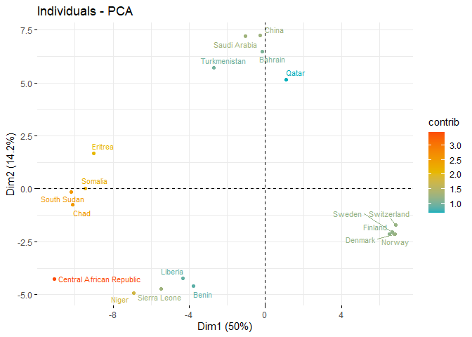

```r
 #fviz_eig(pr.out)
fviz_pca_ind(pr.out.core, labelsize=3,
             col.ind = "contrib", # Color by the quality of representation
             gradient.cols = c("#00AFBB", "#E7B800", "#FC4E07"),
             geom = c("point","text"),
             #select.ind = list(cos2 = 30),
             select.ind= list(name=c(topbotind1,topbotind2)),
             repel = TRUE     # Avoid text overlapping
             )
```

```r
ggsave("CountryPC1PC2.png")
```

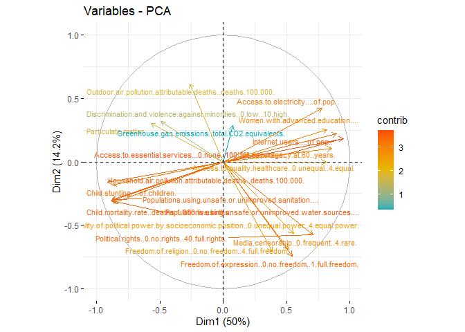

```r
fviz_pca_var(pr.out.core, labelsize=3,
             col.var = "contrib", # Color by contributions to the PC
             gradient.cols = c("#00AFBB", "#E7B800", "#FC4E07"),
             select.var = list(name=c(topbotPC1,topbotPC2)),
             repel = TRUE     # Avoid text overlapping
             )
```

```r
ggsave("PC1PC2.png")
```

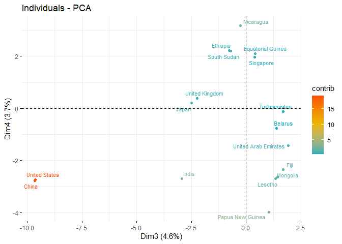

```r
fviz_pca_ind(pr.out.core, labelsize=3,
             col.ind = "contrib", # Color by the quality of representation
             axes=c(3,4),
             gradient.cols = c("#00AFBB", "#E7B800", "#FC4E07"),
             geom = c("point","text"),
             #select.ind = list(cos2 = 30),
             #theme(text = element_text(size = 2)),
             select.ind= list(name=c(topbotind3,topbotind4)),
             repel = TRUE     # Avoid text overlapping
             )
```

```r
ggsave("CountryPC3PC4.png")
```

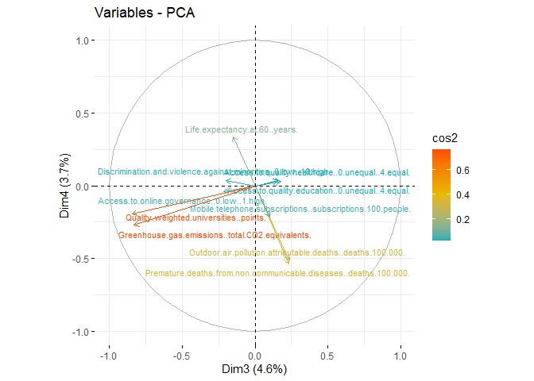

```r
fviz_pca_var(pr.out.core, labelsize=3,
             col.var = "cos2", # Color by contributions to the PC
             gradient.cols = c("#00AFBB", "#E7B800", "#FC4E07"),
             axes=c(3,4),
             select.var = list(name=c(topbotPC3,topbotPC4)),
             repel = TRUE     # Avoid text overlapping
             )
```

```r
ggsave("PC3PC4.png")
```

# 6 An index of our own

Can we come up with a rank based on the PCAs? We can just use the first PCA. In general it is not suggested that we add scores from different PCAs … but if we still go ahead and do that for one more …

```r
spi_ae<-data.frame(sp4.core[,1])#-sp4.core[,2])#-sp4.core[,3]+sp4.core[,4])
rownames(spi_ae)<-rownames(sp4.core)
spi_ae$rank<-rank(-spi_ae)
spi_ae$spirank<-spirank
colnames(spi_ae)<-c("Score","Rank AE","Rank SPI")
spi_ae[order(spi_ae[,2]),][c(1:10,154:163),]
```

```
##                                    Score Rank AE Rank SPI
## Switzerland                     6.858366       1        6
## Norway                          6.808964       2        1
## Denmark                         6.758297       3        2
## Sweden                          6.648665       4        5
## Finland                         6.511241       5        3
## Iceland                         6.417117       6        9
## Luxembourg                      6.400103       7       14
## Japan                           6.300462       8       13
## Canada                          6.227916       9        7
## Germany                         6.215779      10       11
## Niger                          -6.929903     154      157
## Afghanistan                    -7.049628     155      155
## Congo, Democratic Republic of  -7.261324     156      156
## Guinea                         -7.646872     157      154
## Burundi                        -8.000736     158      158
## Eritrea                        -9.027385     159      160
## Somalia                        -9.472981     160      159
## Chad                          -10.126543     161      162
## South Sudan                   -10.183150     162      163
## Central African Republic      -11.074523     163      161
```

###### 6.0.0.0.0.1 End of PCA Analysis for Social Progress data.